$$ 6532142421 $$$$ Pupipat\ Singkhorn $$

# **<<< Only Problem 2 and 4 will be graded >>>**

```python
import matplotlib.pyplot as plt
plt.style.use('seaborn-v0_8-whitegrid')
import numpy as np
import IPython.display as ipd
%matplotlib inline
import os
from scipy import signal,fftpack
from skimage.io import imread
import cv2
```

## Problem 1

Evaluate the convolution of the following signals

1. $ \textrm{rect} \left( \frac{t-a}{a} \right) * \delta (t-b)$
2. $\textrm{rect} \left( \frac{t}{a} \right) * \textrm{rect} \left( \frac{t}{a} \right) $
3. $ t[u(t)-u(t-1)]*u(t) $

## Problem 2

Determine the convolution $y(t) = h(t)*x(t)$ using Graphical Interpretation of the pairs of the signals shown

[figure not shown]

## [optional]

[figure not shown]

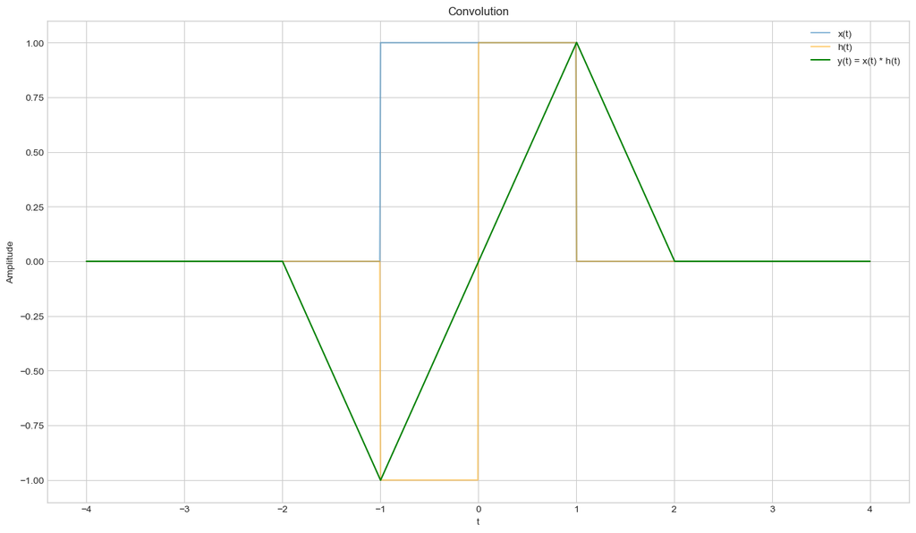

```python
# 1.

t = np.linspace(-4, 4, 1000)

def x(t):
    return np.where((t >= -1) & (t <= 1), 1, 0)

def h(t):
    return np.where((t >= 0) & (t <= 1), 1, 0) - np.where((t >= -1) & (t <= 0), 1, 0)

y = np.convolve(x(t), h(t), mode='same') * (t[1] - t[0]) # Normalize by time step

def plot(t, x, h, y):
    plt.figure(figsize=(16, 9))
    plt.plot(t, x(t), label='x(t)', alpha=0.5)
    plt.plot(t, h(t), label='h(t)', color='orange', alpha=0.5)
    plt.plot(t, y, label='y(t) = x(t) * h(t)', color='green')
    plt.title('Convolution')
    plt.xlabel('t')
    plt.ylabel('Amplitude')
    plt.grid(True)
    plt.legend()
    plt.show()

plot(t, x, h, y)
```

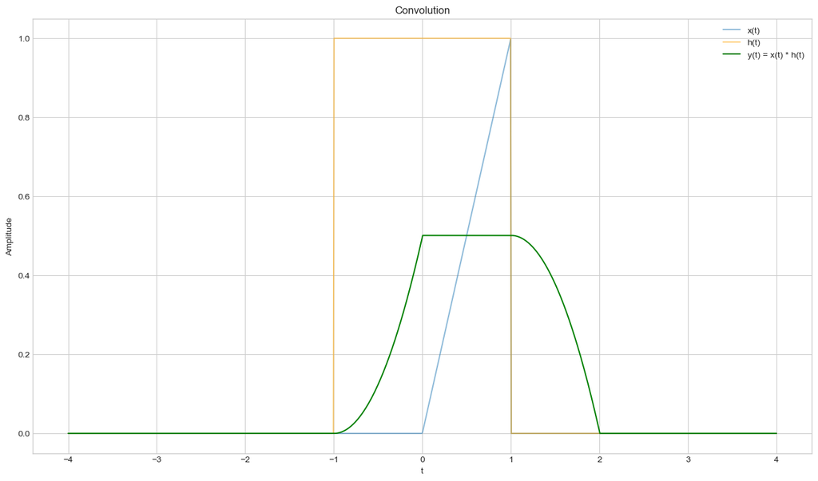

```python
# 2.

t = np.linspace(-4, 4, 1000)

def x(t):
    return np.where((t >= 0) & (t <= 1), t, 0)

def h(t):
    return np.where((t >= -1) & (t <= 1), 1, 0)

y = np.convolve(x(t), h(t), mode='same') * (t[1] - t[0]) # Normalize by time step

plot(t, x, h, y)
```

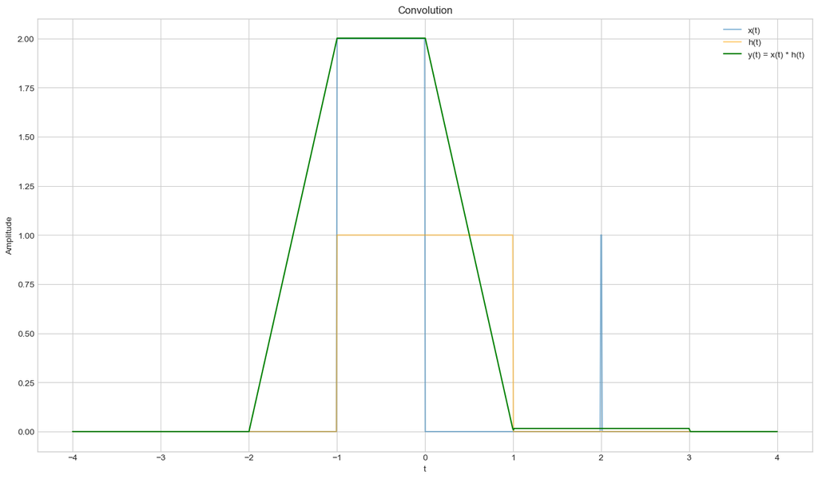

```python
# 3.

t = np.linspace(-4, 4, 1000)

def x(t):
    rect = np.where((t >= -1) & (t <= 0), 2, 0)

    idx = np.argsort(np.abs(t - 2))[:2]
    delta = np.zeros_like(t)
    delta[idx] = 1 # Unit impulse

    return rect + delta

def h(t):
    return np.where((t >= -1) & (t <= 1), 1, 0)

y = np.convolve(x(t), h(t), mode='same') * (t[1] - t[0]) # Normalize by time step

plot(t, x, h, y)
```

## Problem 3

Let $f(t)$ and $g(t)$ be given as follows:

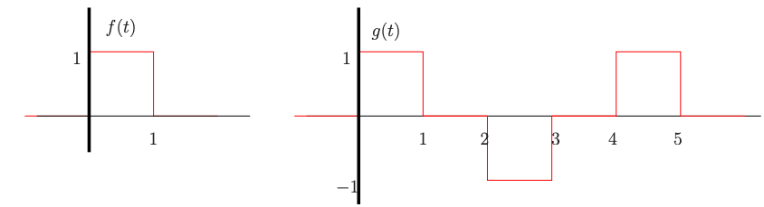

1. sketch the function : $x(t)$ = $f(t)*g(t)$
2. show that if $a(t) = b(t)*c(t)$,then $(Mb(t))*c(t) = Ma(t)$, for any real number M (hint: use the convolution integral formula)

## Problem 4

Find the convolution $y[n] = h[n]*x[n]$ of the following signals:

```python
# Unit step function
def u(n):
    return np.where(n >= 0, 1, 0)
```

$x[n] = \begin{cases} -1 , -5 \leq n \leq -1 \\ 1 , 0 \leq n \leq 4 \end{cases} h[n]=2u[n]$

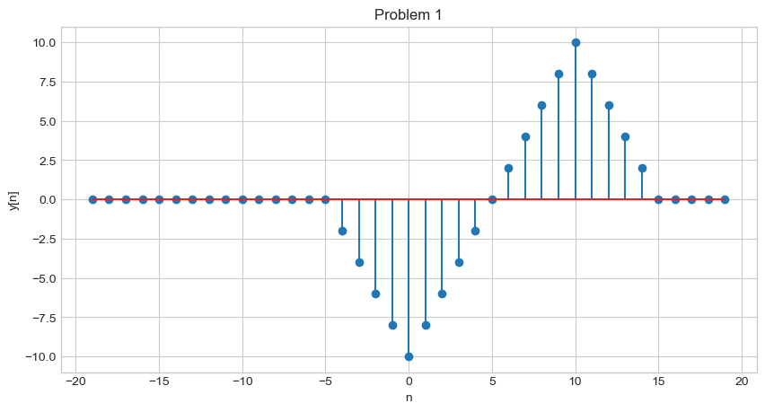

```python
n1 = np.arange(-10, 10)
x1 = np.where((n1 >= -5) & (n1 <= -1), -1, 0) + np.where((n1 >= 0) & (n1 <= 4), 1, 0)
h1 = 2 * u(n1)

y1 = signal.convolve(x1, h1, mode='full')

plt.figure(figsize=(10, 5))
plt.stem(np.arange(len(y1)) - len(h1) + 1, y1)
plt.title('Problem 1')
plt.xlabel('n')
plt.ylabel('y[n]')
plt.grid(True)
plt.show()
```

$x[n] = \left( \frac{1}{2} \right)^n u[n],\, h[n] = \delta[n] +\delta[n-1] + \left( \frac{1}{3} \right)^n u[n]$

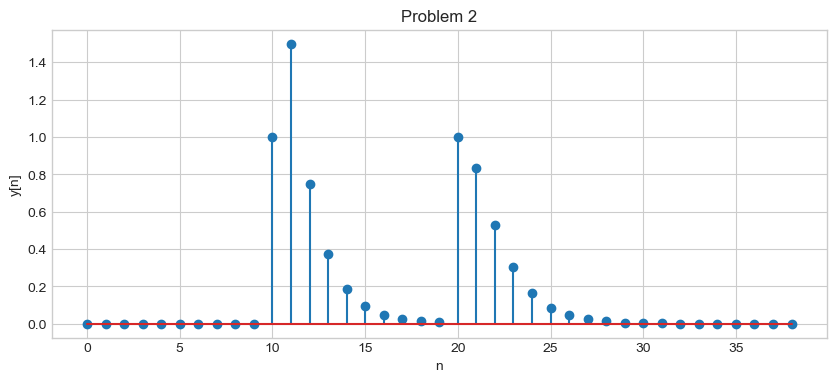

```python
n2 = np.arange(-10, 10)
x2 = (1/2)**n2 * u(n2)
h2 = signal.unit_impulse(20, 0) + signal.unit_impulse(20, 1) + (1/3)**n2 * u(n2)

y2 = signal.convolve(x2, h2, mode='full')

plt.figure(figsize=(10, 4))
plt.stem(np.arange(len(y2)), y2)
plt.title('Problem 2')
plt.xlabel('n')
plt.ylabel('y[n]')
plt.grid(True)
plt.show()
```

$x[n] = u[n],\, h[n] = 1 \; ; 0 \leq n \leq 9 $

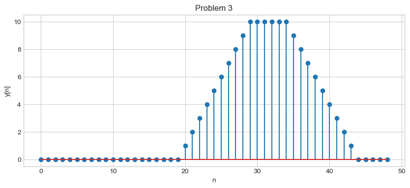

```python
n3 = np.arange(-10, 15)
x3 = u(n3)
h3 = np.where((n3 >= 0) & (n3 <= 9), 1, 0)

y3 = signal.convolve(x3, h3, mode='full')

plt.figure(figsize=(10, 4))
plt.stem(np.arange(len(y3)), y3)
plt.title('Problem 3')
plt.xlabel('n')
plt.ylabel('y[n]')
plt.grid(True)
plt.show()
```

$x[n] = \left( \frac{1}{3} \right)^n u[n],\, h[n] = \delta[n] + \left( \frac{1}{2} \right)^n u[n]$

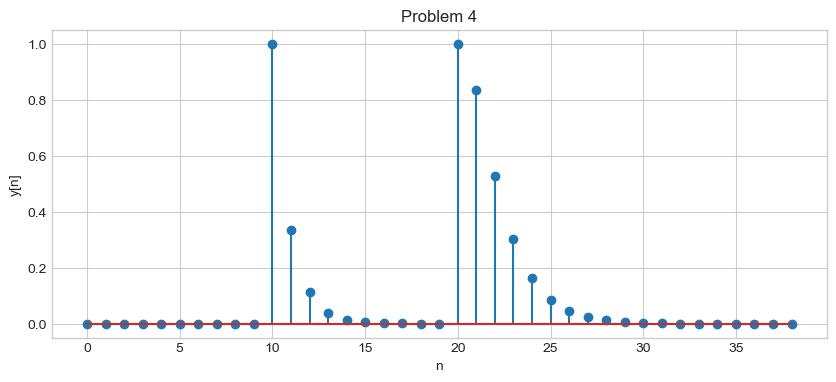

```python
n4 = np.arange(-10, 10)
x4 = (1/3)**n4 * u(n4)
h4 = signal.unit_impulse(20, 0) + (1/2)**n4 * u(n4)

y4 = signal.convolve(x4, h4, mode='full')

plt.figure(figsize=(10, 4))
plt.stem(np.arange(len(y4)), y4)
plt.title('Problem 4')
plt.xlabel('n')
plt.ylabel('y[n]')
plt.grid(True)
plt.show()
```

## Problem 5

Find the convolution $y[n] = h[n]*x[n]$ of the following signals

$x[n] = \left\{ 1,-\frac{1}{2},\frac{1}{4},-\frac{1}{8} ,\frac{1}{16} \right \},\, h[n]=\left\{ 1,-1,1,-1 \right\}$

$x[n] = \left\{ 1,2,3,0,-1, \right \},\, h[n]=\left\{ 2,-1,3,1,-2 \right\}$

$x[n] = \left\{ 3,\frac{1}{2},-\frac{1}{4},1,4 \right \},\, h[n]=\left\{ 2,-1,\frac{1}{2}, -\frac{1}{2} \right\}$

$x[n] = \left\{ -1,\frac{1}{2},\frac{3}{4},-\frac{1}{5},1 \right \},\, h[n]=\left\{ 1,1,1,1,1 \right\}$

## Problem 6

### Problem 6.1 : Convolution - 1D

The following code creates a gaussian pulse and its self convolutions. Study and apply the convolution between signal e and another signal e with noise (e_noise) and write the report to analyze the results.

```python
t = np.linspace(-1, 1, 2 * 100, endpoint=False)
i, q, e = signal.gausspulse(t, fc=5, retquad=True, retenv=True)
plt.plot(t, e, '--',label = 'orignal signal')
plt.legend(loc='upper right')
plt.show()


conv_e = np.convolve(e,e,'same')
plt.plot(t, e, '--',label = 'orignal signal')
plt.plot(t, conv_e, '--',label = 'self conv signal')
plt.legend(loc='upper right')
plt.show()

e_noise = e + np.random.randn(len(e))*2.5
conv_e_noise = np.convolve(e,e_noise,'same')

# TODO : Apply the convolution between signal e and another signal e with noise (e_noise) and check the results
```

[output not shown]

### Problem 6.2

From the self convolution below, when increasing the number of self convolution (now is 8), what is noticeable from the final shape resulted from the convolution?

(HINT 01: Central limit theorem)

(HINT 02: What is Probability Density Function (PDF) of $z$ if $z=x+y$ $?$ )

```python
from scipy.stats import uniform

x = np.linspace(-5,5, 1000)
plt.plot(x, uniform.pdf(x),
       'r-', lw=5, alpha=0.6, label='uniform pdf')

plt.show()


x = np.linspace(-15,15, 10000)
pdf_1 = uniform.pdf(x)
pdf_2 = uniform.pdf(x)

for i in range(8):
    pdf_2 = np.convolve(pdf_2,pdf_1, 'same')

pdf_2 = pdf_2/np.max(pdf_2)
plt.plot(x, pdf_2,'r-', lw=5, alpha=0.6, label='conv uniform')
```

[output not shown]

## Problem 7

### 2D (image) signal convolution:

The following code show the 2D signal (image f(x,y)) and a kernel (diag_line). Study the convolution of the kernel and the image. Apply with "circuits.png" image and analyze the results.

## TODO : Apply diag_line to the "circuits.png image" and analyse the results

```python
!wget https://drive.google.com/uc?id=1hQ8uKocLTjaKmrJm-O4BfZxvLLM1Cfa- -O circuits.png
!wget https://drive.google.com/uc?id=1WoISJ6-FECt-gt6Ovjlfmz89oGH812GM -O hamtaro0.jpg
```

```python
image_path = 'hamtaro0.jpg'

diag_line = np.array([[ 2, -1, -1],
                    [-1, 2, -1],
                    [-1, -1, 2]])

ham = cv2.imread(image_path,0)
plt.figure(figsize=(10,10))
plt.imshow(ham, cmap='gray')
plt.show()
grad = signal.convolve2d(ham,diag_line,boundary='symm',mode='same')
plt.figure(figsize=(10,10))
plt.imshow(grad, cmap='gray')
plt.show()

# TODO : Apply diag_line to the "circuits.png image" and analyse the results
```

[output not shown]

## Problem 8

Are the following systems linear or time invariant?

1. $x(t)$ -> **System(a)** -> $7x(t-1)$
2. $x(t)$ -> **System(b)** -> $cos(2x(t))$
3. $x(t)$ -> **System(c)** -> $t$
4. $x(t)$ -> **System(d)** -> $x(t)+t$